```r
devtools::install_github("JaseZiv/worldfootballR")
library(worldfootballR)
library(tidyverse)
library(ggsoccer)
```

Viewing and filtering match results from England

```r
eng_match_results <- load_match_results(country = "ENG", gender = "M", season_end_year = c(2015:2025), tier = "1st")
```

```
## → Data last updated 2025-02-04 17:32:08.29795408248901 UTC
```

```r
glimpse(eng_match_results)
```

```
## Rows: 4,180
## Columns: 20
## $ Competition_Name <chr> "Premier League", "Premier League", "Premier League",…
## $ Gender           <chr> "M", "M", "M", "M", "M", "M", "M", "M", "M", "M", "M"…
## $ Country          <chr> "ENG", "ENG", "ENG", "ENG", "ENG", "ENG", "ENG", "ENG…
## $ Season_End_Year  <int> 2015, 2015, 2015, 2015, 2015, 2015, 2015, 2015, 2015,…
## $ Round            <chr> NA, NA, NA, NA, NA, NA, NA, NA, NA, NA, NA, NA, NA, N…
## $ Wk               <chr> "1", "1", "1", "1", "1", "1", "1", "1", "1", "1", "2"…
## $ Day              <chr> "Sat", "Sat", "Sat", "Sat", "Sat", "Sat", "Sat", "Sun…
## $ Date             <date> 2014-08-16, 2014-08-16, 2014-08-16, 2014-08-16, 2014…
## $ Time             <chr> "12:45", "15:00", "15:00", "15:00", "15:00", "15:00",…
## $ Home             <chr> "Manchester Utd", "Stoke City", "Leicester City", "QP…
## $ HomeGoals        <dbl> 1, 0, 2, 0, 0, 2, 2, 2, 0, 1, 0, 1, 1, 2, 0, 2, 4, 1,…
## $ Home_xG          <dbl> NA, NA, NA, NA, NA, NA, NA, NA, NA, NA, NA, NA, NA, N…
## $ Away             <chr> "Swansea City", "Aston Villa", "Everton", "Hull City"…
## $ AwayGoals        <dbl> 2, 1, 2, 1, 1, 2, 1, 1, 2, 3, 0, 0, 3, 0, 0, 2, 0, 1,…
## $ Away_xG          <dbl> NA, NA, NA, NA, NA, NA, NA, NA, NA, NA, NA, NA, NA, N…
## $ Attendance       <dbl> 75339, 27478, 31603, 17603, 34977, 25468, 59962, 4473…
## $ Venue            <chr> "Old Trafford", "Bet365 Stadium", "King Power Stadium…
## $ Referee          <chr> "Mike Dean", "Anthony Taylor", "Mike Dean", "Craig Pa…
## $ Notes            <chr> NA, NA, NA, NA, NA, NA, NA, NA, NA, NA, NA, NA, NA, N…
## $ MatchURL         <chr> "https://fbref.com/en/matches/d192bd78/Manchester-Uni…
```

Filtering only Arsenal’s matches

```r
arsenal_decade_results <- filter(eng_match_results, Home == "Arsenal" | Away == "Arsenal")
glimpse(arsenal_decade_results)
```

```
## Rows: 418
## Columns: 20
## $ Competition_Name <chr> "Premier League", "Premier League", "Premier League",…
## $ Gender           <chr> "M", "M", "M", "M", "M", "M", "M", "M", "M", "M", "M"…
## $ Country          <chr> "ENG", "ENG", "ENG", "ENG", "ENG", "ENG", "ENG", "ENG…
## $ Season_End_Year  <int> 2015, 2015, 2015, 2015, 2015, 2015, 2015, 2015, 2015,…
## $ Round            <chr> NA, NA, NA, NA, NA, NA, NA, NA, NA, NA, NA, NA, NA, N…
## $ Wk               <chr> "1", "2", "3", "4", "5", "6", "7", "8", "9", "10", "1…
## $ Day              <chr> "Sat", "Sat", "Sun", "Sat", "Sat", "Sat", "Sun", "Sat…
## $ Date             <date> 2014-08-16, 2014-08-23, 2014-08-31, 2014-09-13, 2014…
## $ Time             <chr> "17:30", "17:30", "16:00", "12:45", "15:00", "17:30",…
## $ Home             <chr> "Arsenal", "Everton", "Leicester City", "Arsenal", "A…
## $ HomeGoals        <dbl> 2, 2, 1, 2, 0, 1, 2, 2, 0, 3, 2, 1, 0, 1, 3, 4, 2, 2,…
## $ Home_xG          <dbl> NA, NA, NA, NA, NA, NA, NA, NA, NA, NA, NA, NA, NA, N…
## $ Away             <chr> "Crystal Palace", "Arsenal", "Arsenal", "Manchester C…
## $ AwayGoals        <dbl> 1, 2, 1, 2, 3, 1, 0, 2, 2, 0, 1, 2, 1, 0, 2, 1, 2, 1,…
## $ Away_xG          <dbl> NA, NA, NA, NA, NA, NA, NA, NA, NA, NA, NA, NA, NA, N…
## $ Attendance       <dbl> 59962, 39490, 31535, 60003, 40013, 59900, 41607, 6000…
## $ Venue            <chr> "Emirates Stadium", "Goodison Park", "King Power Stad…
## $ Referee          <chr> "Jonathan Moss", "Kevin Friend", "Anthony Taylor", "M…
## $ Notes            <chr> NA, NA, NA, NA, NA, NA, NA, NA, NA, NA, NA, NA, NA, N…
## $ MatchURL         <chr> "https://fbref.com/en/matches/fc69768c/Arsenal-Crysta…
```

Filtering out only the xG from the dataset

```r
arsenal_xg <- arsenal_decade_results %>%
  mutate(
    Arsenal_xG = if_else(Home == "Arsenal", Home_xG, Away_xG)
  ) %>%
  select(Date, Arsenal_xG)
glimpse(arsenal_xg)
```

```
## Rows: 418
## Columns: 2
## $ Date       <date> 2014-08-16, 2014-08-23, 2014-08-31, 2014-09-13, 2014-09-20…
## $ Arsenal_xG <dbl> NA, NA, NA, NA, NA, NA, NA, NA, NA, NA, NA, NA, NA, NA, NA,…
```

The xG data only goes back to 2017/18 so there’s a warning with this code. I’m plotting to get a visual idea of the data distribution.

```
## Warning: Removed 128 rows containing missing values or values outside the scale range
## (`geom_line()`).
```

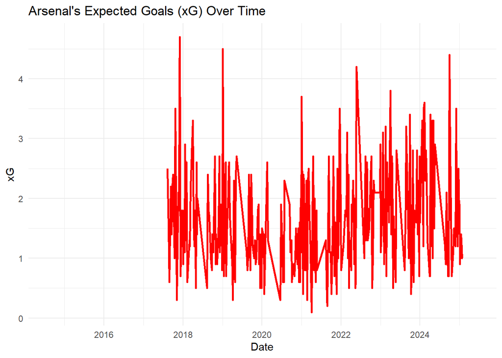

```r
ggplot(arsenal_xg, aes(x = as.Date(Date), y = Arsenal_xG)) +
  geom_line(color = "red", linewidth = 1) +
  labs(
    title = "Arsenal's Expected Goals (xG) Over Time",
    x = "Date",
    y = "xG"
  ) +
  theme_minimal() #' The xG data only goes back to 2017/18 so there's a warning.
```

```r
wenger_arsenal_xg <- arsenal_xg %>%
                       filter(Date >= as.Date("2014-08-16") & Date <= as.Date("2018-05-13")) %>%
                       summarise(Average_xG = mean(Arsenal_xG, na.rm = TRUE)) ## average xG for manager Arsene Wenger
emery_arsenal_xg <- arsenal_xg %>%
                       filter(Date >= as.Date("2018-08-12") & Date <= as.Date("2019-11-23")) %>%
                       summarise(Average_xG = mean(Arsenal_xG, na.rm = TRUE)) ## average xG for manager Unai Emery
arteta_arsenal_xg <- arsenal_xg %>%
                      filter(Date >= as.Date("2019-12-26") & Date <= as.Date("2025-05-25")) %>%
                      summarise(Average_xG = mean(Arsenal_xG, na.rm = TRUE)) ## average xG for manager Mikel Arteta
print(wenger_arsenal_xg)
```

```
##   Average_xG
## 1        1.8
```

```r
print(emery_arsenal_xg)
```

```
##   Average_xG
## 1   1.523529
```

```r
print(arteta_arsenal_xg)
```

```
##   Average_xG
## 1   1.647449
```

While Arteta’s xG seems lower than wenger’s, it’s important to note he joined the club during a turbulent period and is first couple of years were spent rebuilding the club. A more accurate comparison would be to calculate Arteta’s average xG until 2022 and his average xG after, which I’ll do now.

```r
arteta_initial_arsenal_xg <- arsenal_xg %>%
                               filter(Date >= as.Date("2019-12-26") & Date <= as.Date("2022-01-01")) %>%
                               summarise(Average_xG = mean(Arsenal_xG, na.rm = TRUE))
arteta_later_arsenal_xg <- arsenal_xg %>%
                               filter(Date >= as.Date("2022-01-01") & Date <= as.Date("2025-05-25")) %>%
                               summarise(Average_xG = mean(Arsenal_xG, na.rm = TRUE))
print(arteta_initial_arsenal_xg)
```

```
##   Average_xG
## 1   1.364103
```

```r
print(arteta_later_arsenal_xg)
```

```
##   Average_xG
## 1    1.82605
```

When checking, Arteta’s initial xG was 1.36 while his later xG is 1.82. This is a clear discrepancy and shows how Arteta improved Arsenal’s goalscoring chances during his time, and checking his initial and later xG shows how there can be discrepancies in this data when checking. Just filtering by manager may not show the full picture, to see the clear distribution plotting by graph is better.  
For completeness I’ll do the same for Emery however my hypothesis is there won’t be a significant difference. If at all, in Emery’s case the later xG may be worse, which could justify Arsenal’s decision to sack him. I’ll split Emery’s xG across the 2018/19 season and 2019/20 season.  
Doing the same for Wenger is pointless since the data only begins in the 2017/18 season. Wenger was in charge of Arsenal from 1996-2018 so analysing his data for one year seems pointless.

```r
emery_initial_arsenal_xg <- arsenal_xg %>%
  filter(Date >= as.Date("2018-08-12") & Date <= as.Date("2019-05-12")) %>%
  summarise(Average_xG = mean(Arsenal_xG, na.rm = TRUE))
emery_later_arsenal_xg <- arsenal_xg %>%
  filter(Date >= as.Date("2019-08-09") & Date <= as.Date("2019-11-23")) %>%
  summarise(Average_xG = mean(Arsenal_xG, na.rm = TRUE))
print(emery_initial_arsenal_xg)
```

```
##   Average_xG
## 1   1.581579
```

```r
print(emery_later_arsenal_xg)
```

```
##   Average_xG
## 1   1.353846
```

Upon viewing, Emery’s initial xG was 1.58 while his later xG was 1.35.  
This confirms the theory there may be a slight decrease in xG, which could justify Arsenal’s decision to sack him.  
I’ll conclude with my analysis of xG distribution for now. If I need to do it in the future for my questions, I’ll follow this blueprint for whatever team or player I need (for player I’ll use a different function).  
I’ll analyse the distribution of two more variables in this script, passes and carries. In line with my questions, I’ll look at the passes and carries of Raheem Sterling from 2018 to 2025. His ‘prime’ (best years) is widely regarded as being in 2019, so I think we’ll see a downward trend in both.  
defining the seasons Sterling played in

```r
seasons <- 2018:2025
```

I’ll call the player pass and carry stats from the Premier League for 2018-2025 now and store them.

```r
pass_stats <- load_fb_advanced_match_stats(
  country = "ENG",
  gender = "M",
  season_end_year = seasons,
  tier = "1st",
  stat_type = "passing",
  team_or_player = "player"
)
```

```
## → Data last updated 2025-05-11 04:02:14.1068201065063 UTC
```

```r
carry_stats <- load_fb_advanced_match_stats(
  country = "ENG",
  gender = "M",
  season_end_year = seasons,
  tier = "1st",
  stat_type = "possession",
  team_or_player = "player"
)
```

```
## → Data last updated 2025-03-09 16:11:32.9703350067139 UTC
```

Checking to see the column names for passes and carries

```r
glimpse(pass_stats)
```

```
## Rows: 82,395
## Columns: 55
## $ MatchURL           <chr> "https://fbref.com/en/matches/e3c3ddf0/Arsenal-Leic…
## $ League             <chr> "Premier League", "Premier League", "Premier League…
## $ Match_Date         <chr> "2017-08-11", "2017-08-11", "2017-08-11", "2017-08-…
## $ Matchweek          <chr> "Premier League (Matchweek 1)", "Premier League (Ma…
## $ Home_Team          <chr> "Arsenal", "Arsenal", "Arsenal", "Arsenal", "Arsena…
## $ Home_Formation     <chr> "3-4-3", "3-4-3", "3-4-3", "3-4-3", "3-4-3", "3-4-3…
## $ Home_Score         <chr> "4", "4", "4", "4", "4", "4", "4", "4", "4", "4", "…
## $ Home_xG            <dbl> 2.5, 2.5, 2.5, 2.5, 2.5, 2.5, 2.5, 2.5, 2.5, 2.5, 2…
## $ Home_Goals         <chr> "Alexandre Lacazette · 2&rsquor; Danny Welbeck · 45…
## $ Home_Yellow_Cards  <chr> "0", "0", "0", "0", "0", "0", "0", "0", "0", "0", "…
## $ Home_Red_Cards     <chr> "0", "0", "0", "0", "0", "0", "0", "0", "0", "0", "…
## $ Away_Team          <chr> "Leicester City", "Leicester City", "Leicester City…
## $ Away_Formation     <chr> "4-4-1-1", "4-4-1-1", "4-4-1-1", "4-4-1-1", "4-4-1-…
```

[output cut: 42 more lines]

```r
glimpse(carry_stats)
```

```
## Rows: 80,449
## Columns: 55
## $ MatchURL              <chr> "https://fbref.com/en/matches/e3c3ddf0/Arsenal-L…
## $ League                <chr> "Premier League", "Premier League", "Premier Lea…
## $ Match_Date            <chr> "2017-08-11", "2017-08-11", "2017-08-11", "2017-…
## $ Matchweek             <chr> "Premier League (Matchweek 1)", "Premier League …
## $ Home_Team             <chr> "Arsenal", "Arsenal", "Arsenal", "Arsenal", "Ars…
## $ Home_Formation        <chr> "3-4-3", "3-4-3", "3-4-3", "3-4-3", "3-4-3", "3-…
## $ Home_Score            <dbl> 4, 4, 4, 4, 4, 4, 4, 4, 4, 4, 4, 4, 4, 4, 4, 4, …
## $ Home_xG               <dbl> 2.5, 2.5, 2.5, 2.5, 2.5, 2.5, 2.5, 2.5, 2.5, 2.5…
## $ Home_Goals            <chr> "Alexandre Lacazette · 2&rsquor; Danny Welbeck ·…
## $ Home_Yellow_Cards     <chr> "0", "0", "0", "0", "0", "0", "0", "0", "0", "0"…
## $ Home_Red_Cards        <chr> "0", "0", "0", "0", "0", "0", "0", "0", "0", "0"…
## $ Away_Team             <chr> "Leicester City", "Leicester City", "Leicester C…
## $ Away_Formation        <chr> "4-4-1-1", "4-4-1-1", "4-4-1-1", "4-4-1-1", "4-4…
```

[output cut: 42 more lines]

Filtering passing data for Sterling

```r
sterling_pass <- pass_stats %>%
  filter(Player == "Raheem Sterling") %>%
  select(Season_End_Year, Team, Player, Passes_Attempted = Att_Total, Passes_Completed = Cmp_Total, Progressive_Passes = PrgP, Match_Date)
```

Filtering carrying data for Sterling

```r
sterling_carry <- carry_stats %>%
  filter(Player == "Raheem Sterling") %>%
  select(Season_End_Year, Team, Player, Carries = Carries_Carries, Progressive_Carries = PrgC_Carries, DistCarries = TotDist_Carries, Match_Date)
```

I had trouble joining the two dataframes together so I’ll leave them separate for now. It doesn’t impact my analysis.  
Just checking column names and data so I know how to begin my plot.

```r
glimpse(sterling_pass)
```

```
## Rows: 229
## Columns: 7
## $ Season_End_Year    <int> 2018, 2018, 2018, 2018, 2018, 2018, 2018, 2018, 201…
## $ Team               <chr> "Manchester City", "Manchester City", "Manchester C…
## $ Player             <chr> "Raheem Sterling", "Raheem Sterling", "Raheem Sterl…
## $ Passes_Attempted   <chr> "6", "25", "33", "53", "24", "42", "57", "13", "27"…
## $ Passes_Completed   <chr> "6", "17", "21", "48", "21", "30", "43", "13", "22"…
## $ Progressive_Passes <chr> "1", "3", "2", "13", "1", "1", "2", "2", "5", "3", …
## $ Match_Date         <chr> "2017-08-12", "2017-08-21", "2017-08-26", "2017-09-…
```

```r
glimpse(sterling_carry)
```

```
## Rows: 223
## Columns: 7
## $ Season_End_Year     <int> 2018, 2018, 2018, 2018, 2018, 2018, 2018, 2018, 20…
## $ Team                <chr> "Manchester City", "Manchester City", "Manchester …
## $ Player              <chr> "Raheem Sterling", "Raheem Sterling", "Raheem Ster…
## $ Carries             <dbl> 4, 21, 32, 45, 24, 41, 50, 13, 23, 34, 31, 42, 55,…
## $ Progressive_Carries <dbl> 1, 5, 3, 7, 3, 6, 7, 1, 5, 4, 3, 3, 4, 6, 3, 2, 3,…
## $ DistCarries         <dbl> 45, 182, 217, 300, 111, 269, 176, 83, 190, 160, 16…
## $ Match_Date          <chr> "2017-08-12", "2017-08-21", "2017-08-26", "2017-09…
```

I’ll make the values numeric so I can plot a continuous graph.

```r
sterling_pass <- sterling_pass %>%
  mutate(
    Passes_Attempted = as.numeric(Passes_Attempted),
    Passes_Completed = as.numeric(Passes_Completed),
    Progressive_Passes = as.numeric(Progressive_Passes)
  )

sterling_carry <- sterling_carry %>%
  mutate(
    Carries = as.numeric(Carries),
    Progressive_Carries = as.numeric(Progressive_Carries),
    DistCarries = as.numeric(DistCarries)
  )
```

Now that that’s done, I’ll plot six graphs for the six different variables. The code is mostly repetitive for each graph

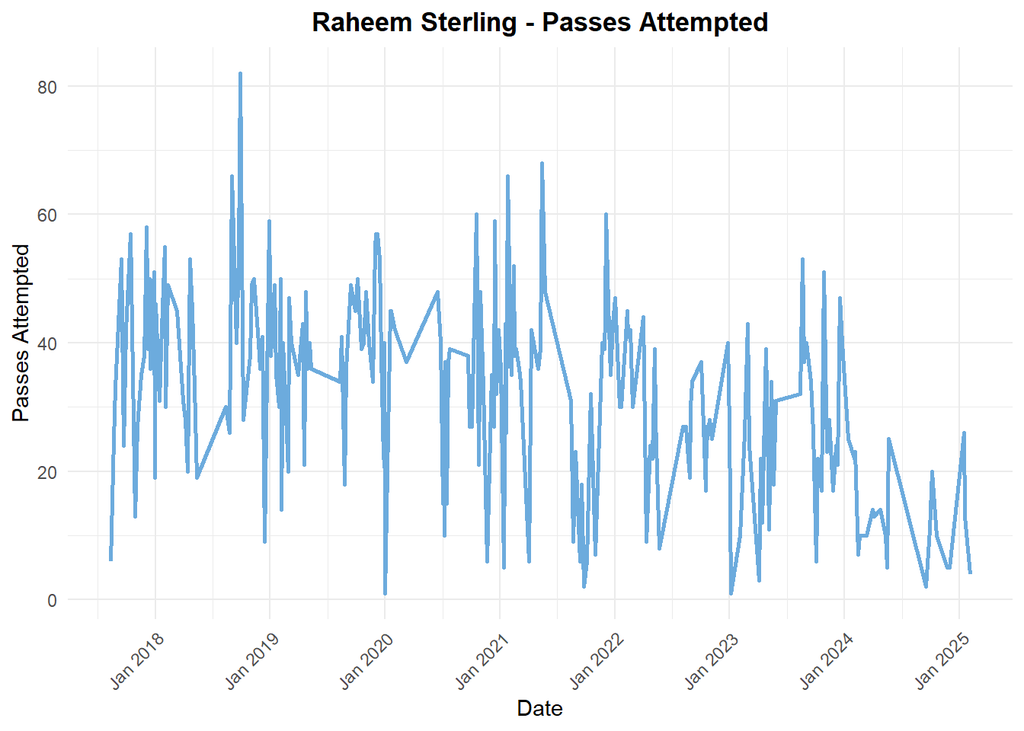

```r
p1 <- ggplot(sterling_pass, aes(x = as.Date(Match_Date), y = Passes_Attempted)) +
  geom_line(color = "#6CABDD", size = 1) +
  labs(title = "Raheem Sterling - Passes Attempted",
       x = "Date",
       y = "Passes Attempted") +
  theme_minimal() +
  theme(plot.title = element_text(hjust = 0.5, face = "bold"),
        axis.text.x = element_text(angle = 45, hjust = 1)) +
  scale_y_continuous(breaks = scales::pretty_breaks(n = 6)) +
  scale_x_date(date_breaks = "1 year", date_labels = "%b %Y")
print(p1)
```

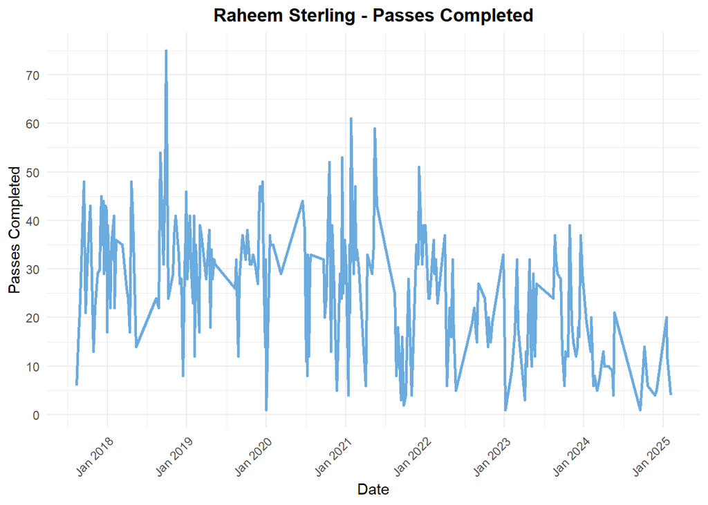

```r
p2 <- ggplot(sterling_pass, aes(x = as.Date(Match_Date), y = Passes_Completed)) +
  geom_line(color = "#6CABDD", size = 1) +
  labs(title = "Raheem Sterling - Passes Completed",
       x = "Date",
       y = "Passes Completed") +
  theme_minimal() +
  theme(plot.title = element_text(hjust = 0.5, face = "bold"),
        axis.text.x = element_text(angle = 45, hjust = 1)) +
  scale_y_continuous(breaks = scales::pretty_breaks(n = 6)) +
  scale_x_date(date_breaks = "1 year", date_labels = "%b %Y")
print(p2)
```

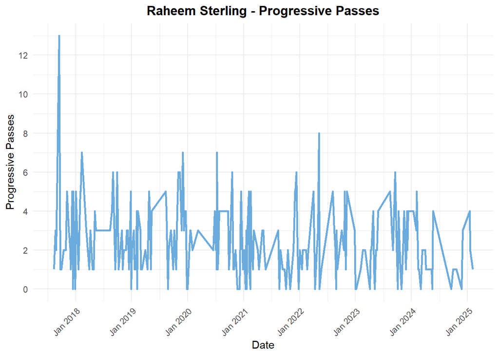

```r
p3 <- ggplot(sterling_pass, aes(x = as.Date(Match_Date), y = Progressive_Passes)) +
  geom_line(color = "#6CABDD", size = 1) +
  labs(title = "Raheem Sterling - Progressive Passes",
       x = "Date",
       y = "Progressive Passes") +
  theme_minimal() +
  theme(plot.title = element_text(hjust = 0.5, face = "bold"),
        axis.text.x = element_text(angle = 45, hjust = 1)) +
  scale_y_continuous(breaks = scales::pretty_breaks(n = 6)) +
  scale_x_date(date_breaks = "1 year", date_labels = "%b %Y")
print(p3)
```

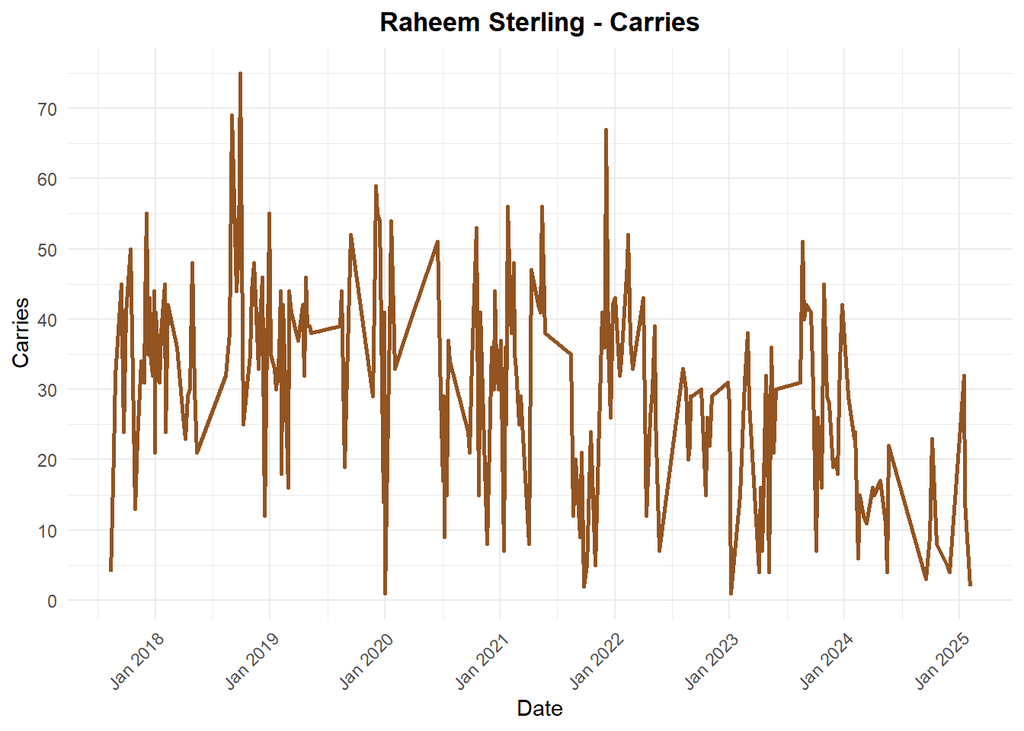

```r
p4 <- ggplot(sterling_carry, aes(x = as.Date(Match_Date), y = Carries)) +
  geom_line(color = "#935422", size = 1) +
  labs(title = "Raheem Sterling - Carries",
       x = "Date",
       y = "Carries") +
  theme_minimal() +
  theme(plot.title = element_text(hjust = 0.5, face = "bold"),
        axis.text.x = element_text(angle = 45, hjust = 1)) +
  scale_y_continuous(breaks = scales::pretty_breaks(n = 6)) +
  scale_x_date(date_breaks = "1 year", date_labels = "%b %Y")
print(p4)
```

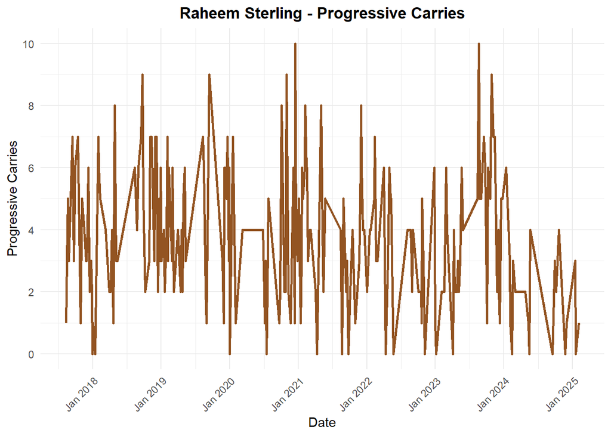

```r
p5 <- ggplot(sterling_carry, aes(x = as.Date(Match_Date), y = Progressive_Carries)) +
  geom_line(color = "#935422", size = 1) +
  labs(title = "Raheem Sterling - Progressive Carries",
       x = "Date",
       y = "Progressive Carries") +
  theme_minimal() +
  theme(plot.title = element_text(hjust = 0.5, face = "bold"),
        axis.text.x = element_text(angle = 45, hjust = 1)) +
  scale_y_continuous(breaks = scales::pretty_breaks(n = 6)) +
  scale_x_date(date_breaks = "1 year", date_labels = "%b %Y")
print(p5)
```

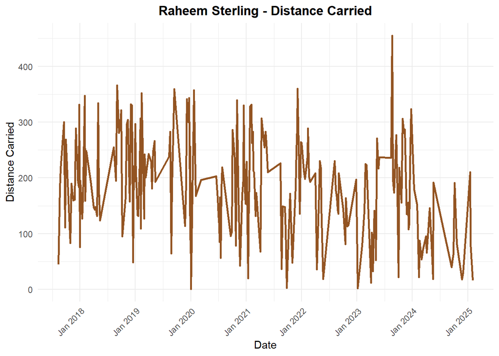

```r
p6 <- ggplot(sterling_carry, aes(x = as.Date(Match_Date), y = DistCarries)) +
  geom_line(color = "#935422", size = 1) +
  labs(title = "Raheem Sterling - Distance Carried",
       x = "Date",
       y = "Distance Carried") +
  theme_minimal() +
  theme(plot.title = element_text(hjust = 0.5, face = "bold"),
        axis.text.x = element_text(angle = 45, hjust = 1)) +
  scale_y_continuous(breaks = scales::pretty_breaks(n = 6)) +
  scale_x_date(date_breaks = "1 year", date_labels = "%b %Y")
print(p6)
```

After a lot of code and viewing the graphs, there seems to be a slight downward trend. This is apparently especially prevalent in mid 2024, which coincides with his time at Arsenal. To conclude my analysis of this data distribution, I’ll analyse Sterling’s stats across his time playing for Manchester City, Chelsea and Arsenal (on loan).  
Converting Match_Date to Date format for both datasets

```r
sterling_pass <- sterling_pass %>%
  mutate(Match_Date = as.Date(Match_Date))

sterling_carry <- sterling_carry %>%
  mutate(Match_Date = as.Date(Match_Date))
```

Defining the date periods

```r
city_start <- as.Date("2018-01-01")
city_end <- as.Date("2022-07-01")
chelsea_start <- as.Date("2022-07-01")
chelsea_end <- as.Date("2024-08-01")
arsenal_start <- as.Date("2024-08-01")
arsenal_end <- as.Date("2025-05-31")
```

Calculating City period averages (Jan 2018 - Jul 2022)

```r
city_pass_data <- sterling_pass %>%
  filter(Match_Date >= city_start & Match_Date < city_end)

city_carry_data <- sterling_carry %>%
  filter(Match_Date >= city_start & Match_Date < city_end)

passes_attempted_city <- mean(city_pass_data$Passes_Attempted, na.rm = TRUE)
passes_completed_city <- mean(city_pass_data$Passes_Completed, na.rm = TRUE)
progressive_passes_city <- mean(city_pass_data$Progressive_Passes, na.rm = TRUE)
carries_city <- mean(city_carry_data$Carries, na.rm = TRUE)
progressive_carries_city <- mean(city_carry_data$Progressive_Carries, na.rm = TRUE)
distcarries_city <- mean(city_carry_data$DistCarries, na.rm = TRUE)
```

Calculating Chelsea period averages (Jul 2022 - Aug 2024)

```r
chelsea_pass_data <- sterling_pass %>%
  filter(Match_Date >= chelsea_start & Match_Date < chelsea_end)

chelsea_carry_data <- sterling_carry %>%
  filter(Match_Date >= chelsea_start & Match_Date < chelsea_end)

passes_attempted_chelsea <- mean(chelsea_pass_data$Passes_Attempted, na.rm = TRUE)
passes_completed_chelsea <- mean(chelsea_pass_data$Passes_Completed, na.rm = TRUE)
progressive_passes_chelsea <- mean(chelsea_pass_data$Progressive_Passes, na.rm = TRUE)
carries_chelsea <- mean(chelsea_carry_data$Carries, na.rm = TRUE)
progressive_carries_chelsea <- mean(chelsea_carry_data$Progressive_Carries, na.rm = TRUE)
distcarries_chelsea <- mean(chelsea_carry_data$DistCarries, na.rm = TRUE)
```

Calculating Arsenal period averages (Aug 2024 - May 2025)

```r
arsenal_pass_data <- sterling_pass %>%
  filter(Match_Date >= arsenal_start & Match_Date <= arsenal_end)

arsenal_carry_data <- sterling_carry %>%
  filter(Match_Date >= arsenal_start & Match_Date <= arsenal_end)

passes_attempted_arsenal <- mean(arsenal_pass_data$Passes_Attempted, na.rm = TRUE)
passes_completed_arsenal <- mean(arsenal_pass_data$Passes_Completed, na.rm = TRUE)
progressive_passes_arsenal <- mean(arsenal_pass_data$Progressive_Passes, na.rm = TRUE)
carries_arsenal <- mean(arsenal_carry_data$Carries, na.rm = TRUE)
progressive_carries_arsenal <- mean(arsenal_carry_data$Progressive_Carries, na.rm = TRUE)
distcarries_arsenal <- mean(arsenal_carry_data$DistCarries, na.rm = TRUE)
```

Finally, I’ll pull all the averages into a dataframe for easier viewing.

```r
sterling_summary <- data.frame(
  Period = c("Manchester City", "Chelsea", "Arsenal"),
  Passes_Attempted = c(passes_attempted_city, passes_attempted_chelsea, passes_attempted_arsenal),
  Passes_Completed = c(passes_completed_city, passes_completed_chelsea, passes_completed_arsenal),
  Progressive_Passes = c(progressive_passes_city, progressive_passes_chelsea, progressive_passes_arsenal),
  Carries = c(carries_city, carries_chelsea, carries_arsenal),
  Progressive_Carries = c(progressive_carries_city, progressive_carries_chelsea, progressive_carries_arsenal),
  DistCarries = c(distcarries_city, distcarries_chelsea, distcarries_arsenal)
)

print(sterling_summary)
```

```
##            Period Passes_Attempted Passes_Completed Progressive_Passes  Carries
## 1 Manchester City         36.13380        29.556338           2.549296 34.28676
## 2         Chelsea         23.94915        17.830508           2.322034 23.64407
## 3         Arsenal         10.66667         8.333333           1.444444 11.11111
##   Progressive_Carries DistCarries
## 1            3.992647   202.07353
## 2            3.406780   154.49153
## 3            1.555556    81.55556
```

Sterling’s stats did indeed drop across clubs, especially at Arsenal.